# Segunda Tarea de Microeconmetría Aplicada

Miguel Lerdo de Tejada Flores

lunes 22, marzo 2021

# Pregunta 1

Iniciemos explorando la base de datos. Elabora una tabla con estadísticas descriptivas básicas para todas las variables de la base de datos. Incluye en tu tabla número de observaciones, media, desviación estándar, mínimo y máximo. [Tip de R: utiliza el comando *summary* o *stargazer*.]

| variable | mean | n | min | 0.1 | median | 0.9 | max | std_dev |
| --- | --- | --- | --- | --- | --- | --- | --- | --- |
| dvaxx_per_mill | 6.202922e+03 | 51 | 2883.00 | 4897.00 | 6245.0 | 7306.00 | 8667.00 | 1.072861e+03 |
| sh_vaxx | 8.627843e+00 | 51 | 6.13 | 7.16 | 8.5 | 10.45 | 14.01 | 1.504349e+00 |
| inc_pc | 5.142396e+04 | 51 | 42134.00 | 45420.00 | 50155.0 | 56356.00 | 67277.00 | 5.518428e+03 |
| stad | 2.156863e-01 | 51 | 0.00 | 0.00 | 0.0 | 1.00 | 1.00 | 4.153902e-01 |
| cases_7d | 8.559784e+03 | 51 | 304.00 | 875.00 | 4846.0 | 20481.00 | 51611.00 | 1.145239e+04 |
| deaths_7d | 2.654314e+02 | 51 | 0.00 | 11.00 | 95.0 | 561.00 | 2898.00 | 4.956491e+02 |
| dem | 4.600000e-01 | 50 | 0.00 | 0.00 | 0.0 | 1.00 | 1.00 | 5.034574e-01 |
| hosp_curr | 8.880196e+02 | 51 | 20.00 | 67.00 | 440.0 | 1921.00 | 5508.00 | 1.303562e+03 |
| sh_65old | 1.689412e+01 | 51 | 11.40 | 14.70 | 16.9 | 19.50 | 21.30 | 2.022416e+00 |
| health_emp | 3.292604e+05 | 51 | 25410.00 | 56950.00 | 218710.0 | 721830.00 | 1670370.00 | 3.526178e+05 |
| sh_copd | 6.874510e+00 | 51 | 4.10 | 4.50 | 6.5 | 9.40 | 12.30 | 1.949548e+00 |
| sh_afro | 1.276078e+01 | 51 | 1.20 | 2.20 | 9.6 | 28.00 | 47.20 | 1.076805e+01 |

# Pregunta 2

Ahora analizaremos la relación entre el número de **vacunados diarios por millón de habitantes** (**dvaxx_per_mill**) y el **ingreso personal per cápita** (**inc_pc**).

1. Elabora un **scatterplot** entre **dvaxx_per_mill** (eje $Y$) y el logaritmo natural de **inc_pc** (eje $X$). Incluye en dicha gráfica la recta que se obtiene al realizar una estimación por MCO entre ambas variables. Reporta en formato de ecuación el resultado de la estimación del modelo e interpreta el coeficiente relevante. [Tip de R: Puedes realizar **scatterplots** con *geom_point* y agregar el ajuste de MCO con *geom_smooth(method=“lm”)* de la librería *ggplot2*. Para realizar estimaciones por MCO (simples y múltiples) utiliza el comando *lm*.]

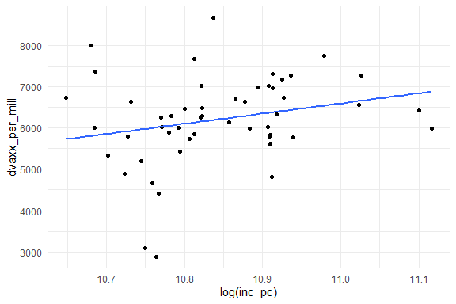

La ecuación estimada es $dvaxx\_per\_mill=\underset{(15386.8955)}{-20494.9406}+\underset{(1412.8465)}{2462.3524}\;ln(inc\_pc)$.

2. Considerando la especificación anterior, estima regresiones cuantílicas para los cuantiles 10, 50 y 90. Reporta los resultados de dichas regresiones en formato de ecuación, grafica en un diagrama de dispersión las tres regresiones cuantílicas y la regresión de MCO (la cual estimaste en el inciso anterior).

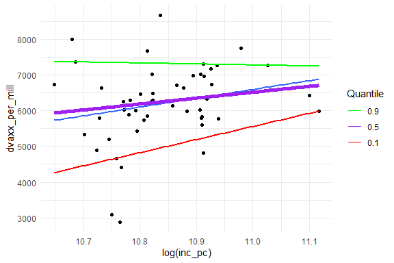

La regresión mediana tiene ecuación $dvaxx\_per\_mill=\underset{(19401.0439)}{-11634.3130}+\underset{(1792.2102)}{1650.0359}\;inc\_pc$, la del cuantil 0.1 $dvaxx\_per\_mill=\underset{(29393.9510)}{-34773.7113}+\underset{(2682.3128)}{3666.3915}\;inc\_pc$ y la de cuantil 0.9 es $dvaxx\_per\_mill=\underset{(23925.0450)}{10311.5648}+\underset{(2191.0718)}{-276.1281}\;inc\_pc$.

3. Recordemos que las regresiones cuantílicas nos predicen el valor del cuantil $Q$ de la variable dependiente, condicional en los valores de $X$. Consideremos un indicador común de desigualdad: el *ratio* del cuantil 90 sobre el cuantil 10.[^1] Utilizando los coeficientes del inciso anterior calcula la diferencia de este ratio entre dos valores específicos de **inc_pc**: $45,000$ y $60,000$.

En el caso de $inc\_pc=45,000$, el ratio toma el valor 1.6305 y en el caso de $inc\_pc=60,00$ toma el valor 1.3072 y la diferencia es 0.3234.

4. Utilizando bootstrap (500 simulaciones) calcula un intervalo de confianza de $90\%$ para la respuesta del inciso anterior. [Tip: para cada simulación debes repetir las regresiones cuantílicas relevantes.]

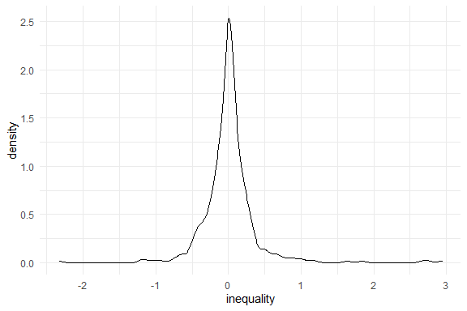

Parece que suponer normalidad es un supuesto muy fuerte. Entonces presento el intervalo empírico. El intervalo deseado es (-0.4491,0.5006).

5. Por último, imagina que quisieras utilizar tu resultado de la estimación del inciso (a) para predecir **dvaxx_per_mill** para México. Lleva a cabo este ejercicio y calcula el resultado de la predicción contra el valor verdadero de **dvaxx_per_mill** para México. Enumera algunas razones para explicar por qué predecir el valor de México con el resultado de (a) pudiera no ser adecuado.

De acuerdo al [Banco Mundial](https://datos.bancomundial.org/indicador/NY.GDP.PCAP.CD?locations=MX), el ingreso per cápita de México a Diciembre 2019 fue de 9946.034 dólares. Entonces la predicción utilizndo este dato sería $\widehat{dvaxx\_per\_mill}=$ 2170.8388 mientras que el valor verdadero a la fecha de corte (a partir de [Our world in data](https://ourworldindata.org/covid-vaccinations?country=~MEX)) es $dvaxx_per_mill=$821.

Predecir el valor de México con la estimación de Estados Unidos puede no ser adecuado ya de entrada en la propia especificación falta controlar por otras variables (ubicación geográfica, urbanización etc) es decir no tiene tanta validez interna. Además, el contexto en el que se aplican las vacunas en México es muy distinto a los estados de Estados Unidos (llegada de vacunas, restricciones de higiene, etc) por lo que tampoco tendría mucha validez externa aunque sí tuviera externa.

# Pregunta 3

Ahora compararemos dos modelos alternativos de MCO para explicar a **dvaxx_per_mill**: (i) utilizando solo **inc_pc** (sin logaritmo) como variable explicativa y (ii) utilizando un polinomio de segundo grado de **inc_pc**.

1. Elabora un **scatterplot** entre **dvaxx_per_mill** y **inc_pc** agregando el resultado de las dos estimaciones. Reporta ambas estimaciones en formato de ecuación. Visualmente, >cuál de las dos alternativas crees que es mejor para modelar a **dvaxx_per_mill**?

**Disclaimer:** para esttimar la especificación cuadrática utilicé el código:

```r
reg_mco2 <- lm(dvaxx_per_mill ~ poly(inc_pc,2),vacunas_f)
```

En lugar de crear una nueva variable que fuera $inc\_pc^2$, ya que me evito algunos problemas de correlación y optimizo memoria.

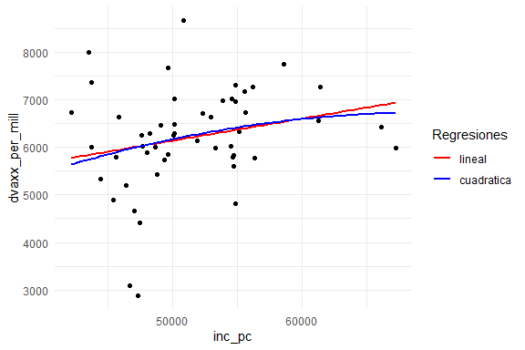

Las ecuaciones son $dvaxx\_per\_mill=\underset{(1420.9033)}{3820.6919}+\underset{(0.0262)}{0.0463}\;inc\_pc$ para la estimación lineal y $dvaxx\_per\_mill=\underset{(148.6613)}{6202.9216}+\underset{(1013.9909)}{1807.6671}\;inc\_pc+\underset{(941.8188)}{-427.3690}\;inc\_pc^2$ para la cuadrática.

2. Para comparar a ambos modelos llevemos a cabo lo siguiente: calcula los residuales después de llevar a cabo la estimación, elévalos al cuadrado (que es lo que hacemos en la minimización de OLS) y promédialos. Este es un estadístico que comúnmente se reporta con las regresiones y conocémos como *Mean Squarred Error* (MSE).

El MSE del primer modelo es 1064389.7904 y el del segundo es 1060808.5302.

3. Como no sabemos si estos promedios son pequeños o grandes, quisiéramos compararlos contra la desviación estándar de **dvaxx_per_mill**, dado que los errores viven en el mismo eje que $Y$. Pero como calculamos los errores al cuadrado, los compararemos contra el cuadrado de la desviación estándar, es decir, la varianza de **dvaxx_per_mill** [Ojo, al calcular esta varianza divide entre $N$ en vez de $N-1$ como típicamente hacemos en el calculo de la varianza muestral.]. Reporta el ratio de MSE entre la varianza de **dvaxx_per_mill** para ambas estimaciones.

El ratio del primer modelo es 0.9432 y el del segundo es 0.9400.

4. Llevando a cabo el inciso anterior, indica qué estadístico ampliamente conocido en las regresiones haz derivado implícitamente si calculas:
   $$Estad = 1-\frac{MSE}{Var(dvaxx\_per\_mill)}$$
   La famosa $R^2$.
5. Es casualidad que este estadístico sea mayor para la especificación cuadrática? >Cuál es el valor que obtendrías para este estadístico si llevaras a cabo una regresión de **dvaxx_per_mill** solo contra la constante ($Y_i=\beta_0$)? Basado en tus resultados anteriores puedes explicar por qué?

En ese caso $\beta_0=\mathbb{E}[Y]\;\;\implies\;\;MSE=\sum_{i=1}^n(y_i-\mathbb{E}[Y])^2=\mathbb{V}[Y]\;\;\therefore\;\;R^2=0$.

Por lo que podemos intuir que la $R^2$ es creciente en el número de variables independientes.

# Pregunta 4

Ahora analizaremos diferentes mediciones de vacunación y su relación con otras variables económicas, sociodemográficas, políticas y sanitarias. Para esto, deberás realizar las estimaciones que se incluyen en el Cuadro *tab_regs*, que se encuentra al final del documento[^2]. *Ojo:* Las líneas horizontales en algunas variables (—) significan que NO debes incluir esta variable en la estimación de dicha columna. Utiliza errores heterocedásticos y agrega los asteriscos que indiquen nivel de significancia: * 10%, ** 5% y *** 1%. [Tip de R: Para estimar errores heterocedásticos, utiliza el comando *vcovHC* de la librería *sandwich*. En dicho comando deberás indicar el nombre con el que guardaste tu estimación *lm* y errores del tipo *HC1* (i.e. *vcovHC(nombre_modelo,type=‘HC1’)*). Para crear tablas con resultados de regresiones puedes utilizar el comando *stargazer* de la librería homónima.]

|  | *Dependent variable:* |  |  |  |  |
| --- | --- | --- | --- | --- | --- |
|  | log(dvaxx_per_mill) | dvaxx_per_mill | sh_vaxx |  | dst_sp |
|  | (1) | (2) | (3) | (4) | (5) |
| stad | 0.006 | 175.335 | 0.612 | 19.756 | -0.108 |
|  | (0.087) | (398.991) | (0.378) | (31.365) | (0.177) |
| log(inc_pc) | 0.557** | 2,112.551 | 1.369 | 1.455 | 1.044 |
|  | (0.264) | (1,458.335) | (2.061) | (2.725) | (0.675) |
| fat_rate | 2.494** | 14,995.370*** |  |  | 0.220 |
|  | (0.984) | (4,928.780) |  |  | (2.892) |
| hosp_curr | -0.00004* | -0.222** |  |  |  |
|  | (0.00002) | (0.106) |  |  |  |
| sh_65old | -0.003 |  | -0.007 | -0.004 | 0.047 |
|  | (0.019) |  | (0.177) | (0.189) | (0.037) |
| log(health_emp) |  |  | -0.860*** |  |  |
|  |  |  | (0.289) |  |  |
| dem | 0.022 |  | 0.208 |  | 0.039 |
|  | (0.053) |  | (0.402) |  | (0.152) |
| sh_copd |  | -77.180 |  |  |  |
|  |  | (81.135) |  |  |  |
| sh_afro |  | -13.475 |  | -0.029 |  |
|  |  | (15.217) |  | (0.022) |  |
| stad:log(inc_pc) |  |  |  | -1.865 |  |
|  |  |  |  | (2.892) |  |
| Constant | 2.686 | -16,259.480 | 4.189 | -6.620 | -11.640 |
|  | (2.919) | (16,089.170) | (23.072) | (30.789) | (7.363) |
| Observations | 50 | 51 | 50 | 51 | 50 |
| R<sup>2</sup> | 0.183 | 0.227 | 0.232 | 0.076 | 0.077 |
| Adjusted R<sup>2</sup> | 0.069 | 0.121 | 0.145 | -0.026 | -0.027 |
| Residual Std. Error | 0.194 (df = 43) | 1,005.672 (df = 44) | 1.394 (df = 44) | 1.524 (df = 45) | 0.512 (df = 44) |
| F Statistic | 1.609 (df = 6; 43) | 2.151* (df = 6; 44) | 2.664** (df = 5; 44) | 0.743 (df = 5; 45) | 0.738 (df = 5; 44) |
| *Note:* | *p<0.1; **p<0.05; ***p<0.01 |  |  |  |  |

# Pregunta 5

Considerando los resultados del Cuadro 2, interpreta de la forma más específica posible los siguientes coeficientes. (Nota: lleva a cabo la interpretación del valor estimado de los coeficientes a pesar de que resulten no significativos.):

1. **stad** en la columna (1).
- Caeterias paribus,el uso de estadios deportivos como centros de vacunación está asociado con un aumento de 0.6% en la cantidad de personas vacunadas diariamente por cada millón de habitantes (a la fecha de corte).
2. **fat_rate** en la columna (1).
- Caeterias paribus,un aumento de un punto porcentual en la tasa de fatalidad está asociado con un aumento de 2.494% en la cantidad de personas vacunadas diariamente por cada millón de habitantes (a la fecha de corte).
3. **hosp_curr** en la columna (2).
- Caeterias paribus,un paciente más hospitalizado por COVID está asociado a una disminución de 0.222 en la cantidad de personas vacunadas diariamente por cada millón de habitantes (a la fecha de corte).
4. **sh_copd** en la columna (2).
- Caeterias paribus,un aumento de un punto porcentual en el porcentaje de adultos con problemas pulmonares está asociado con una disminución de 77.180 en la cantidad de personas vacunadas diariamente por cada millón de habitantes (a la fecha de corte).
5. **ln(inc_pc)** en la columna (3).
- Caeterias paribus,un aumento de 1% en el ingreso personal per cápita está asociado con un aumento de .01369 puntos porcentuales en el porcentaje de la población del estado que ha recibido el total de dosis de la vacuna.
6. **log(health_emp)** en la columna (3).
- Caeterias paribus,un aumento de 1% en la cantidad de trabajadores del sector salud está asociado con una disminución de 0.0086 puntos porcentuales en el porcentaje de la población del estado que ha recibido el total de dosis de la vacuna.
7. **stad** en la columna (5).
- Caeterias paribus,el uso de estadios deportivos como centros de vacunación está asociado con una disminución de 0.108 en la probabilidad de que el porcentaje de la población del estado que ha recibido el total de dosis de la vacuna (a la fecha de corte) sea mayor que la mediana.
8. **log(inc_pc)** en la columna (5).
- Caeterias paribus,un aumento de 1% en el ingreso personal per cápita está asociado con un aumento de 0.01044 en la probabilidad de que el porcentaje de la población del estado que ha recibido el total de dosis de la vacuna (a la fecha de corte) sea mayor que la mediana.
1. **sh_old** en la columna (5).
- Caeterias paribus,un aumento de un punto porcentual en el porcentaje población con 65 años o más está asociado con un aumento de 0.047 en la probabilidad de que el porcentaje de la población del estado que ha recibido el total de dosis de la vacuna (a la fecha de corte) sea mayor que la mediana.

# Pregunta 6

**Derivada parcial, derivada total y partial-out.** En los siguientes incisos nos enfocaremos en la diferencia del promedio de **sh_vaxx** entre los estados gobernados por un demócrata ($dem=1$) y los estados gobernados por un republicano ($dem=0$). Compararemos el valor estimado, así como intervalos de confianza de $90\%$

1. Empieza por interpretar el valor estimado de **dem** que obtienes en la especificación (3).[^3] Utilizando los resultados de la estimación calcula el intervalo de confianza de $90\%$.

Que un estado sea demócrata está asociado a un aumento de 0.208 puntos porcentuales en el porcentaje de la población del estado que ha recibido el total de dosis de la vacuna (a la fecha de corte).

El intervalo es (-0.4529, 0.8692).

2. Para generar el estimador más simple calcula la media de **sh_vaxx** para los estados con $dem=0$ y $dem=1$ y reporta la diferencia. Muestra cómo podrías haber obtenido ese mismo valor utilizando una regresión simple. Deberás estimar la regresión simple correspondiente y reportarla con formato de ecuación. Utilizando el resultado de la regresión reporta también el intervalo de confianza de $90\%$.

La media para estados con $dem=0$ es 8.6656 mientras que para los estados con $dem=1$ es 8.5270. La diferencia es -0.1386.

Si estimamos la regresión $sh\_vaxx=\beta_0+\beta_1dem$ tenemos que $\mathbb{E}[sh\_vaxx|dem=1]-\mathbb{E}[sh\_vaxx|dem=0]=\beta_1$, por lo que al estimar dicha especificación obetemos que la diferencia en medias es $\beta_1=$-0.1386. La ecuación estimada es $sh\_vaxx=\underset{(0.3478)}{8.6656}+\underset{(0.4162)}{-0.1386}\;dem$. El intervalo de confianza correspodiente es (-0.8231, 0.5459).

3. **Derivada total.** Para cada una de las variables que utilizamos como controles en la especificación (3) calcula su media para los grupos $dem=0$ y $dem=1$. Utilizando estos valores y el resultado de la especificación (3), calcula el valor de **sh_vaxx** que el modelo predice para $dem=0$ y $dem=1$. Reporta esta diferencia y calcula el intervalo de confianza de $90\%$.

Las medias toman los valores

|  | stad | inc_pc | sh_65old | health_emp |
| --- | --- | --- | --- | --- |
| dem=0 | 0.2222 | 50641.22 | 16.8370 | 281293.3 |
| dem=1 | 0.2174 | 51701.83 | 17.1565 | 397436.5 |

El valor predecido para $dem=0$ es 8.2461 y para $dem=1$ es 8.1803. La diferencia es `-0.0658.

Para construir el intervalo de confianza notemos que la respuesta media
$$\mathbb{E}[sh\_vaxx|dem=1]-\mathbb{E}[sh\_vaxx|dem=0]$$
Es igual a:

$$=\left(\begin{array}{l} \beta_0 & \beta_1 & \beta_2 & \beta_3 & \beta_4 & \beta_5 \end{array}\right)\left(\begin{array}{l} 0\\\mathbb{E}_n[stad|dem=1]-\mathbb{E}_n[stad|dem=0] \\ \mathbb{E}_n[log(inc\_pc)|dem=1]-\mathbb{E}_n[log(inc\_pc)|dem=0] \\ \mathbb{E}_n[sh\_65old|dem=1]-\mathbb{E}_n[sh\_65old|dem=0] \\ \mathbb{E}_n[log(health\_emp)|dem=1]-\mathbb{E}_n[log(health\_emp)|dem=0] \\ 1\end{array}\right)=\overline{\beta}\alpha$$

Entonces sabemos que:
$$\hat{\beta}\alpha\sim\mathcal{N}(\overline{\beta}\alpha,\alpha'\Sigma\alpha),\;\;\Sigma=\mathbb{E}(U^2_iX_iX′_i)$$
Por tanto nuestro intervalo es:

$$(\hat{\beta}\alpha-\Phi^{-1}(0.95)*\sqrt{\alpha'\hat{\Sigma}\alpha}\;,\;\hat{\beta}\alpha+\Phi^{-1}(0.95)*\sqrt{\alpha'\hat{\Sigma}\alpha})$$

Que numéricamente toma el valor (-0.6963, 0.5647).

También reporto el intervalo obtenido por el método bootstrap. Haciendo mil remuestreos aleatorios obtengo la siguiente distribución para la diferencia de las predicciones:

[figure not shown]

Notemos que suponer normalidad no parece un problema, por lo que el intervalo deseado es (-0.6970, 0.5890).

4. Haz dos regresiones por separado. En cada una de ellas utiliza los mismos controles que la especificación (3). La primera regresión llévala a cabo sólo con las observaciones de $dem=0$ y la segunda solo con las observaciones de $dem=1$. Utilizando los valores promedio que calculaste en el inciso anterior para los controles vuelve a llevar a cabo la predicción de **sh_vaxx** para $dem=0$ y $dem=1$. Nuevamente reporta la diferencia y un intervalo de confianza de $90\%$.

El valor predecido para $dem=0$ es 8.1859 y para $dem=1$ es 8.4240. La diferencia es 0.2382.

Veamos el intervalo de manera analítica. La respuesta media
$$\mathbb{E}[sh\_vaxx^{dem=1}]-\mathbb{E}[sh\_vaxx^{dem=0}]$$
Es igual a:

$$=\left(\begin{array}{l} \beta_1^{dem=1} & \beta_2^{dem=1} & \beta_3^{dem=1} & \beta_4^{dem=1} \end{array}\right)\left(\begin{array}{l} \mathbb{E}_n[stad^{dem=1}] \\ \mathbb{E}_n[log(inc\_pc)^{dem=1}] \\ \mathbb{E}_n[sh\_65old^{dem=1}] \\ \mathbb{E}_n[log(health\_emp)^{dem=1}]\end{array}\right)$$
$$-\left(\begin{array}{l}\beta_1^{dem=0} & \beta_2^{dem=0} & \beta_3^{dem=0} & \beta_4^{dem=0}\end{array}\right)\left(\begin{array}{l}\mathbb{E}_n[stad^{dem=0}] \\ \mathbb{E}_n[log(inc\_pc)^{dem=0}] \\ \mathbb{E}_n[sh\_65old^{dem=0}] \\ \mathbb{E}_n[log(health\_emp)^{dem=0}]\end{array}\right)$$
Que de manera más simple se ve:
$$=\overline{\beta^{dem=1}}\alpha^{dem=1}-\overline{\beta^{dem=0}}\alpha^{dem=0}$$
Pero cuya varianza es:
$$Var(\overline{\beta^{dem=1}}\alpha^{dem=1}-\overline{\beta^{dem=0}}\alpha^{dem=0})=Var(\overline{\beta^{dem=1}}\alpha^{dem=1})+Var(\overline{\beta^{dem=0}}\alpha^{dem=0})-2\underline{Cov(\overline{\beta^{dem=1}},\overline{\beta^{dem=0}})}$$
El último término subrayado es muy difícil de estimar con las herramientas de clase, por lo que mejor voy a reportar únicamente el intervalo por el método bootstrap.

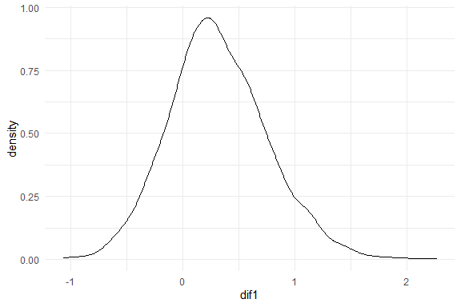

De nuevo la normalidad no parece ser un problema, por lo que el intervalo es (-0.4079, 1.0417).

5. **Interacciones.** Repite la estimación de la especificación (3) pero ahora agregando las interacciones de cada uno de los controles con la variable **dem** (i.e. una interacción sería $stad*dem$, otra sería $\log{(inc\_pc)}*dem$ y asi sucesivamente para todos los controles). Nuevamente utilizando los valores promedio para los controles lleva a cabo la predicción de **sh_vaxx** para $dem=0$ y $dem=1$ y reporta el intervalo de confianza de $90\%$.

El valor predecido para $dem=0$ es 8.1859 y para $dem=1$ es 8.4240. La diferencia es `0.2382.

Para construir el intervalo de confianza notemos que la respuesta media
$$\mathbb{E}[sh\_vaxx|dem=1]-\mathbb{E}[sh\_vaxx|dem=0]$$
Es igual a:

$$=\left(\begin{array}{l} \beta_0 & \beta_1 & \beta_2 & \beta_3 & \beta_4 & \beta_5 & \beta_6 & \beta_7 \end{array}\right)\left(\begin{array}{l} \\ 0 \\ 1\\ \mathbb{E}_n[stad|dem=1]-\mathbb{E}_n[stad|dem=0] \\ \mathbb{E}_n[log(inc\_pc)|dem=1]-\mathbb{E}_n[log(inc\_pc)|dem=0] \\ \mathbb{E}_n[sh\_65old|dem=1]-\mathbb{E}_n[sh\_65old|dem=0] \\ \mathbb{E}_n[log(health\_emp)|dem=1]-\mathbb{E}_n[log(health\_emp)|dem=0] \\ \mathbb{E}_n[dem*stad|dem=1]\\\mathbb{E}_n[dem*log(inc\_pc)|dem=1]\\\mathbb{E}_n[dem*sh\_65old|dem=1] \\\mathbb{E}_n[dem*log(health\_emp)|dem=1]\end{array}\right)=\overline{\beta}\alpha$$

Entonces sabemos que:
$$\hat{\beta}\alpha\sim\mathcal{N}(\overline{\beta}\alpha,\alpha'\Sigma\alpha),\;\;\Sigma=\mathbb{E}(U^2_iX_iX′_i)$$
Por tanto nuestro intervalo es:

$$(\hat{\beta}\alpha-\Phi^{-1}(0.95)*\sqrt{\alpha'\hat{\Sigma}\alpha}\;,\;\hat{\beta}\alpha+\Phi^{-1}(0.95)*\sqrt{\alpha'\hat{\Sigma}\alpha})$$

Que numéricamente toma el valor (-0.4165, 0.8929).

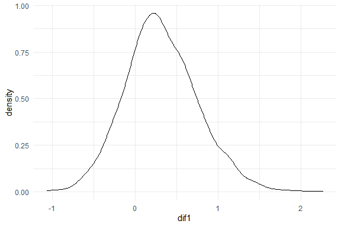

6. **Partial-out.** Lleva a cabo los siguientes pasos: (i) realiza una estimación de $dem$ (como variable dependiente) contra todos los controles y repórtala con formato de ecuación; (ii) utilizando los resultados de esta regresión obten los residuales; (iii) lleva a cabo una regresión simple de **sh_vaxx** contra los residuales que obtuviste en el paso anterior y repórtala con formato de ecuación. >Qué valor de los anteriores que habías calculado obtuviste?

La ecuación estimada es $sh\_vaxx=\underset{(0.2150)}{8.6018}+\underset{(0.3874)}{0.2082}\;residuales$. Estoy estimando el coeficiente de $dem$ en la especificación 3. La intuición detrás es que los residuales de
$$\operatorname{dem} = \alpha + \beta_{1}(\operatorname{stad}) + \beta_{2}(\operatorname{log(inc\_pc)}) + \beta_{3}(\operatorname{sh\_65old}) + \beta_{4}(\operatorname{log(health\_emp)}) + \epsilon$$
contienen toda la información que afecta a $dem$ que no proviene de los controles i.e. por construcción los residuales son ortogonales a los controles. Entonces al estimar
$$\operatorname{sh\_vaxx} = \alpha + \beta_{1}(\operatorname{residuals}) + \epsilon$$
estamos encontrando el efecto de $dem$ en $sh\_vaxx$ controlando implícitamente por las otras variables de la especificación 3.

7. Para finalizar lleva a cabo una gráfica en la que compares los distintos intervalos de confianza que obtuviste para la diferencia del promedio de **sh_vaxx**. Imagina que trabajas en un periódico muy prestigiado y que al ver tus cálculos, tu jefe te pregunta cuál de ellos deben reportar en una noticia que están por publicar. >Cuál de estas le sugerirías y por qué? Indica qué detalles técnicos econométricos debes reportar junto con el cálculo en la nota periodística para evitar meterte en problemas y que te vayan a acusar de malversar información o, peor aún, que vayan a denunciar a tu periódico por publicar cosas falsas y pierdas tu trabajo.

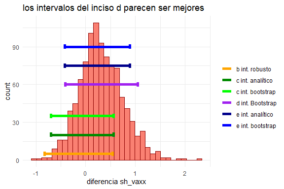

[^1]: Este indicador señala cuántas veces mayor es el valor del cuantil $90$ respecto al $10$.
[^2]: Para realizar la estimación de la columna (5) deberás crear la variable **dst_sp**. Dicha variable es una dummy que toma el valor de 1 si la variable **sh_vaxx** es mayor a la mediana.
[^3]: Siempre que hablemos de la especificación (3) en este ejercicio, estamos haciendo referencia a la tercera columna del Cuadro 2.